# Investigating the impact of severe weather events on public health and the economy

Ioannis Moros

June 18, 2017

# Synopsis

Storms and other severe weather events can cause both public health and economic problems for communities and municipalities. Many severe events can result in fatalities, injuries, and property damage, and preventing such outcomes to the extent possible is a key concern.

This paper explores the U.S. National Oceanic and Atmospheric Administration’s (NOAA) storm database. This database tracks characteristics of major storms and weather events in the United States, including when and where they occur, as well as estimates of any fatalities, injuries, and property damage.

The aim of this analysis is to identify which types of events are most harmful with respect to population health and which types of events have the greatest economic consequences.

The results of the analysis show that tornadoes are the most harmful weather event with respect to population health, in terms of both injuries and fatalities. Regarding the total economic impact, floods are the most destructive event. Most property losses are attributed to floods, while drought is responsible for the most damage to crops.

# R/Knit setup

Before the actual data processing we define the knitr parameters and require the necessary R packages.

```r
knitr::opts_chunk$set(echo = TRUE, warning = FALSE, message = FALSE, cache = TRUE)
```

```r
## Required packages
require(plyr)
require(reshape2)
require(ggplot2)
```

# Data Processing

1. Download and read the raw data.

```r
if(!file.exists("./data")) {
        dir.create("./data")
        url <- "https://d396qusza40orc.cloudfront.net/repdata%2Fdata%2FStormData.csv.bz2"
        file_dest <- "./data/repdata%2Fdata%2FStormData.csv.bz2"
        download.file(url, file_dest)
}

A <- read.csv("./data/repdata%2Fdata%2FStormData.csv.bz2")
```

2. Subset the raw table to include only the variables of interest

```r
Asub <- subset(A, select = c("EVTYPE", "FATALITIES", "INJURIES",
                             "PROPDMG", "PROPDMGEXP", "CROPDMG", "CROPDMGEXP"))
```

3. Investigate the variables that hold the exponential component of economic and health damage.

```r
summary(Asub$PROPDMGEXP)
```

```
##             -      ?      +      0      1      2      3      4      5
## 465934      1      8      5    216     25     13      4      4     28
##      6      7      8      B      h      H      K      m      M
##      4      5      1     40      1      6 424665      7  11330
```

```r
summary(Asub$CROPDMGEXP)
```

```
##             ?      0      2      B      k      K      m      M
## 618413      7     19      1      9     21 281832      1   1994
```

4. In order to get the actual value of the damage, these 2 variables will need to be converted to numeric, then multiplied by the respective value of damage. Notice that the variables contain both uppercase and lower case values. As such, the first step is to convert all the values to uppercase.

```r
Asub$PROPDMGEXP <- toupper(Asub$PROPDMGEXP)
Asub$CROPDMGEXP <- toupper(Asub$CROPDMGEXP)
```

5. Now we are ready to convert their values to numeric.

```r
Asub$CROPDMGEXP <- revalue(Asub$CROPDMGEXP, c("?" = 1,
                                        "0" = 1,
                                        "2" = 10^2,
                                        "K" = 10^3,
                                        "M" = 10^6,
                                        "B" = 10^9
))

Asub$CROPDMGEXP <- as.numeric(as.character(Asub$CROPDMGEXP))
Asub$CROPDMGEXP[is.na(Asub$CROPDMGEXP)] <- 1

Asub$PROPDMGEXP <- revalue(Asub$PROPDMGEXP, c("?" = 1,
                                              "+" = 1,
                                              "-" = 1,
                                              "0" = 1,
                                              "1" = 1,
                                              "2" = 10^2,
                                              "H" = 10^2,
                                              "3" = 10^3,
                                              "K" = 10^3,
                                              "4" = 10^4,
                                              "5" = 10^5,
                                              "6" = 10^6,
                                              "M" = 10^6,
                                              "7" = 10^7,
                                              "8" = 10^8,
                                              "B" = 10^9
))

Asub$PROPDMGEXP <- as.numeric(as.character(Asub$PROPDMGEXP))
Asub$PROPDMGEXP[is.na(Asub$PROPDMGEXP)] <- 1
```

6. Let’s take a look at the levels of the EXP variables now.

```r
levels(as.factor(Asub$CROPDMGEXP))
```

```
## [1] "1"     "100"   "1000"  "1e+06" "1e+09"
```

```r
levels(as.factor(Asub$PROPDMGEXP))
```

```
## [1] "1"     "100"   "1000"  "10000" "1e+05" "1e+06" "1e+07" "1e+08" "1e+09"
```

7. Calculate the total amount of damage and store it as a new variable within the same matrix.

```r
Asub$cropdamage <- Asub$CROPDMG * Asub$CROPDMGEXP
Asub$propdamage <- Asub$PROPDMG * Asub$PROPDMGEXP
```

8. First for the economic damage - Create 3 aggregate matrices with the total crop/property/total economic damage by type of event. Then create a 4th matrix that combines the other 3 (column-bound) and rename the columns.

```r
Crop_dmg_agr <- aggregate(cropdamage ~ EVTYPE, data = Asub, FUN = sum)
Prop_dmg_agr <- aggregate(propdamage ~ EVTYPE, data = Asub, FUN = sum)
Econ_dmg_agr <- aggregate(cropdamage + propdamage ~ EVTYPE, data = Asub, FUN = sum)

Econ_dmg_full <- cbind(Econ_dmg_agr, Crop_dmg_agr[2], Prop_dmg_agr[2])
colnames(Econ_dmg_full) <- c("event", "total", "crop", "property")
```

9. Order the matrices created in step 8 by damage (descending). Then, only keep the first 10 rows of the full economic damage matrix, i.e. the top 10 most impactful types of events with respect to all types of economic damage.

```r
Crop_dmg_agr <- arrange(Crop_dmg_agr, desc(cropdamage))
Prop_dmg_agr <- arrange(Prop_dmg_agr, desc(propdamage))
Econ_dmg_agr <- arrange(Econ_dmg_agr, desc(Econ_dmg_agr[2]))
Econ_dmg_full <- arrange(Econ_dmg_full, desc(Econ_dmg_full[2]))

Econ_dmg_full <- Econ_dmg_full[1:10, ]
```

10. Create a long version of the full combined matrix. This will be useful later to construct the plots.

```r
E_melt <- melt(data = Econ_dmg_full, id.vars = "event", value.name = "damage")
```

11. Repeat steps 8-10 to create and transform similar matrices for health damage.

```r
Injuries_agr <- aggregate(INJURIES ~ EVTYPE, data = Asub, FUN = sum)
Fatalities_agr <- aggregate(FATALITIES ~ EVTYPE, data = Asub, FUN = sum)
Health_dmg_agr <- aggregate(FATALITIES + INJURIES ~ EVTYPE, data = Asub, FUN = sum)

Health_dmg_full <- cbind(Health_dmg_agr, Injuries_agr[2], Fatalities_agr[2])
colnames(Health_dmg_full) <- c("event", "total", "injuries", "fatalities")

Injuries_agr <- arrange(Injuries_agr, desc(INJURIES))
Fatalities_agr <- arrange(Fatalities_agr, desc(FATALITIES))
Health_dmg_agr <- arrange(Health_dmg_agr, desc(Health_dmg_agr[2]))
Health_dmg_full <- arrange(Health_dmg_full, desc(Health_dmg_full[2]))

Health_dmg_full <- Health_dmg_full[1:10, ]

H_melt <- melt(data = Health_dmg_full, id.vars = "event", value.name = "count")
```

# Results

1. Weather events responsible for the most damage to crops.

```r
head(Crop_dmg_agr, 5)
```

```
##        EVTYPE  cropdamage
## 1     DROUGHT 13972566000
## 2       FLOOD  5661968450
## 3 RIVER FLOOD  5029459000
## 4   ICE STORM  5022113500
## 5        HAIL  3025954473
```

2. Weather events that have caused the most property losses.

```r
head(Prop_dmg_agr, 5)
```

```
##              EVTYPE   propdamage
## 1             FLOOD 144657709807
## 2 HURRICANE/TYPHOON  69305840000
## 3           TORNADO  56947380677
## 4       STORM SURGE  43323536000
## 5       FLASH FLOOD  16822673979
```

3. Weather events that have caused the most total economic damage

```r
head(Econ_dmg_agr, 5)
```

```
##              EVTYPE cropdamage + propdamage
## 1             FLOOD            150319678257
## 2 HURRICANE/TYPHOON             71913712800
## 3           TORNADO             57362333947
## 4       STORM SURGE             43323541000
## 5              HAIL             18761221986
```

4. Weather events responsible for the most fatalities

```r
head(Fatalities_agr, 5)
```

```
##           EVTYPE FATALITIES
## 1        TORNADO       5633
## 2 EXCESSIVE HEAT       1903
## 3    FLASH FLOOD        978
## 4           HEAT        937
## 5      LIGHTNING        816
```

5. Weather events that have caused the most injuries

```r
head(Injuries_agr, 5)
```

```
##           EVTYPE INJURIES
## 1        TORNADO    91346
## 2      TSTM WIND     6957
## 3          FLOOD     6789
## 4 EXCESSIVE HEAT     6525
## 5      LIGHTNING     5230
```

6. Weather events that have the biggest impact on population health

```r
head(Health_dmg_agr, 5)
```

```
##           EVTYPE FATALITIES + INJURIES
## 1        TORNADO                 96979
## 2 EXCESSIVE HEAT                  8428
## 3      TSTM WIND                  7461
## 4          FLOOD                  7259
## 5      LIGHTNING                  6046
```

This can be visualised better in the following two plots.

7. Plot of economic damage by type of event.

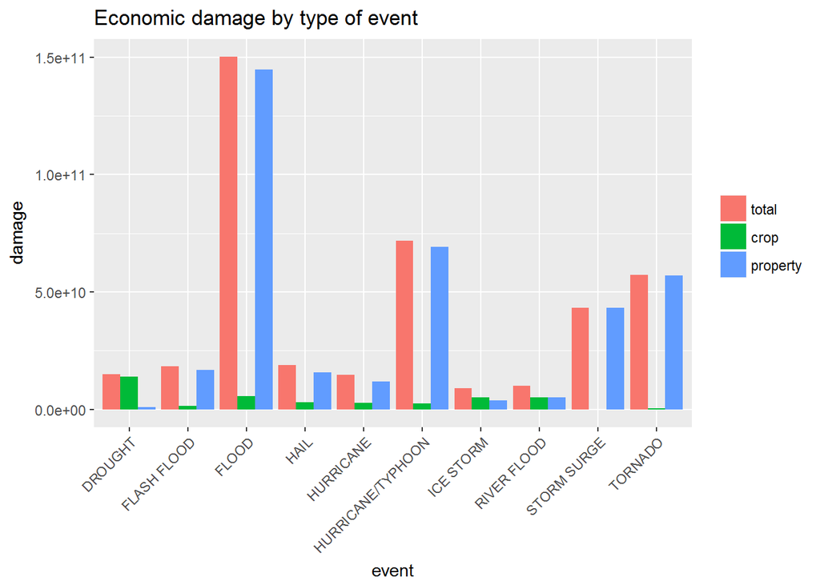

```r
g <- ggplot(E_melt, aes(event, damage, fill = variable))
g + geom_bar(position = "dodge", stat = "identity") +
        theme(legend.title = element_blank(),
              axis.text.x = element_text(angle = 45, hjust = 1)) +
        ggtitle("Economic damage by type of event")
```

8. Plot of health damage by type of event.

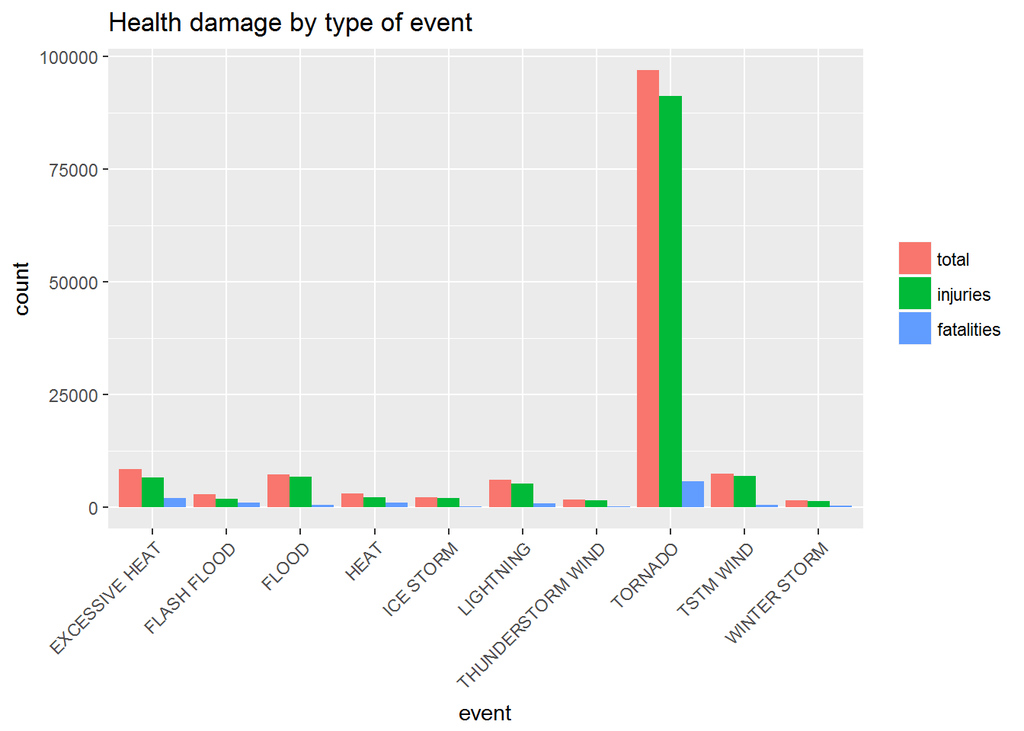

```r
p <- ggplot(H_melt, aes(event, count, fill = variable))
p + geom_bar(position = "dodge", stat = "identity") +
        theme(legend.title = element_blank(),
              axis.text.x = element_text(angle = 45, hjust = 1)) +
        ggtitle("Health damage by type of event")
```

The results presented above reveal that tornadoes are the most harmful weather event with respect to population health, in terms of both injuries and fatalities. Regarding the total economic impact, floods are the most destructive weather event overall. Most properies have been lost due to floods, while most crops are destroyed by drought.